# Demonstrate imputeTestbench on a naturally occurring time series.

Arush Banerjee

#### Reference: https://cran.r-project.org/web/packages/imputeTestbench/imputeTestbench.pdf

## 1. Choice of Dataset

I have chosen DAX(German Stock Market Index) from the EuStockMarkets dataset for this test.

I chose this dataset as it satisfies the requirements of the easy test (univariate by choosing the DAX), and in the future can also be used for multivariate imputation.

This dataset has **high sampling frequency** and is **stochastic in the short term and compounding in the long term** unlike datasets on seasonal data like temp making it ideal for our use case.

## 2. Importing and Plotting the Original Data

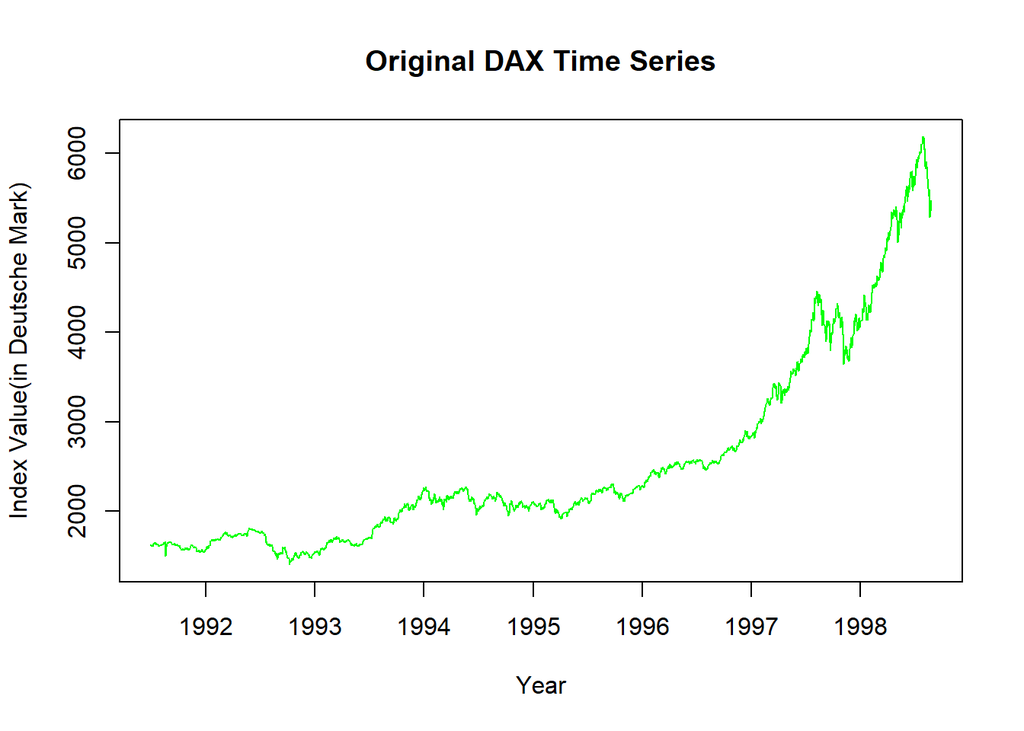

```r
library(imputeTestbench)


data("EuStockMarkets")
dax_ts <- EuStockMarkets[, "DAX"]  #taking the dax time series from the dataset

plot(dax_ts,
     main= "Original DAX Time Series",
     xlab="Year",
     ylab="Index Value(in Deutsche Mark)",
     col="green")
```

This graph is **approximately of exponential type** showing the continued growth of German stock market in these years but also the economic crisis such as of 1997.

## 3. Demonstrating the imputeTestbench package

We will apply three different methods of imputation (“na_mean”, “na_interpolation” and “na.locf”) on the dataset and compare their accuracy.

```r
results <- impute_errors(
  dataIn= dax_ts,
  methods = c("na_interpolation", "na.locf", "na_mean"),
  errorParameter = "rmse", #Gives Root Mean Square Error
  missPercentFrom = 10,
  missPercentTo = 90,
  interval = 10, #Taking Miss Percent from 10 to 90 at an interval of 10
  repetition = 10
)

print(results)
```

```
## $Parameter
## [1] "rmse"
##
## $MissingPercent
## [1] 10 20 30 40 50 60 70 80 90
##
## $na_interpolation
## [1]  7.032728 10.717245 13.883688 17.346403 21.269057 25.583040 30.815631
## [8] 37.012165 51.543698
##
## $na.locf
## [1]  10.31872  16.33172  20.31391  26.97572  32.72078  39.03230  48.51673
## [8]  66.53473 103.05416
##
## $na_mean
## [1]  343.5666  476.7190  595.4870  688.6462  766.6843  837.5613  907.4789
## [8]  965.5503 1032.0742
```

## 4. Plotting the errors of different methods

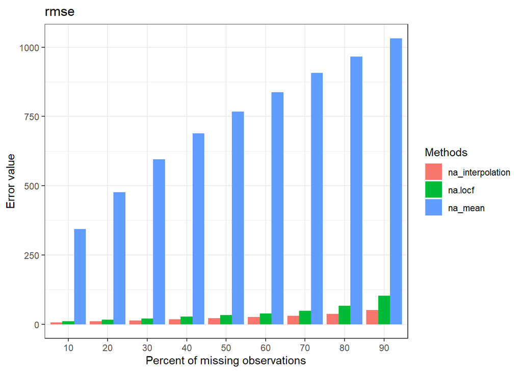

```r
plot_errors(results, plotType = 'bar')
```

## 5. Plotting the imputations of different methods at 50% missing data

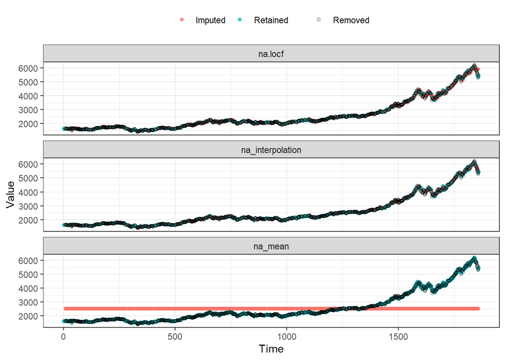

```r
plot_impute(dataIn = dax_ts,
            methods= c("na_interpolation", "na.locf", "na_mean"),
            missPercent = 50,
            showmiss = TRUE
)
```

## 6. Observations from the Plots of errors

**Mean Imputation** consistently has the **highest error** because it ignores the time-dependent nature of stock prices.

**LOCF and Interpolation** perform similarly on this dataset, but as missingness increases, the gaps become wider, and **Linear Interpolation outperformed LOCF** because it utilizes the future’s information as well for the gap.

In a real-world trading bot, you cannot use interpolation because you don’t know tomorrow’s price yet. You are forced to use LOCF.

## 7. Future Scope

As the different EU stock markets are highly interrelated, thus a bear market in one index gives a high probability that the other markets will also be bearish.

Thus in the future, this dataset can be used for the multivariate time series implementation of imputeTestbench.